# Shallow Water, Smaller Waves: Why Depth Explains So Much About Limits to Australia’s Biggest Storm Waves—but Not Everything

14 September 2026

[figure not shown]

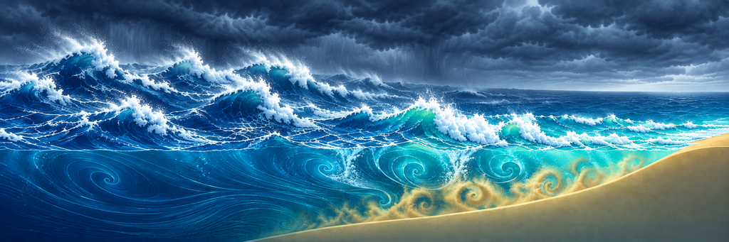

# 1 Why do the biggest ocean storm waves become smaller as they move closer to Australia’s shoreline?

Latitude describes the broad storm-wave climate, but shallow water and regional coastal processes strongly modify the waves that reach Australia’s shelves and coastlines.  
This is an educational explainer of the basic concepts for surfers, students, educators and readers curious about the fundamental physical controls on coastal wave climate. It is not a local surf forecast, navigation product or engineering-design assessment.  
**This explainer is structured so** the main sections follow key questions. Each question is answered first with a simplified blue breakout response for readers who want to skim, followed by explanatory discussion, figures and maps for readers who want to wade further into the topic. Equations, methods and reproducible R code are also provided for readers who want to dive deeply into the technical detail.

This regional explainer follows [*A World of Waves: Why Latitude Explains So Much About the Biggest Waves—but Not Everything*](https://ausclimateservice.github.io/latitude-and-big-waves/Global_Hs_AEP_latitude_model_comparison.html), which found that latitude by itself explained more than half of the variation in mapped deep-water extreme significant wave heights for both the 1-year and 40-year Average Recurrence Intervals (ARIs). This is because latitude reflects major features of the Earth’s climate system, including the broad organisation of wind belts, storm tracks and the differences between tropical and mid-latitude wave climates. However, the global maps also showed that locations at the same latitude can experience substantial differences in wave conditions. Factors such as the size of ocean basins, storm exposure, swell pathways, sheltering by land and regional weather systems all influence extreme waves in ways that latitude alone cannot capture. Those regional differences were generally larger for the less-frequent, more extreme 40-year ARI events. Near coastlines, lower-than-expected wave heights were also often associated with shallow continental shelves, which can reduce the size of incoming waves before they reach the coast.

Using the Australian CCHaPS model, this web-based explainer investigates the same question closer to Australia’s shoreline, where water is shallower and local bathymetry increasingly modifies storm waves. It estimates 1-year and 40-year extreme significant wave heights, then uses straightforward one-line equations to represent the simple concepts of depth and latitude. Comparing these relationships with the full CCHaPS numerical-wave-model results shows where additional coastal processes matter.

**A quick guide to the jargon of an ocean-wave climate scientist**

| Term | Plain-language meaning |
| --- | --- |
| CCHaPS | The Australian Climate Service Coupled Coastal Hazard Prediction System: the national circulation-and-wave model used here to estimate shelf and coastal wave conditions. |
| Significant wave height, $H_s$ | The average height of the highest one-third of waves. It describes a sea state, not the single largest wave. |
| Water depth, $h$ | The average vertical distance between the seabed and water surface at a CCHaPS output location. |
| ARI | Average Recurrence Interval. A 40-year ARI does **not** mean a storm lasts 40 years; it describes how rare the estimated wave height is. |
| AEP | Annual Exceedance Probability: the chance that a level is exceeded in any year. |
| Depth-limited breaking | Wave-energy loss that occurs when waves become too large for the available water depth. |
| Residual | CCHaPS wave height minus the depth-and-latitude estimate. Positive values mean CCHaPS is higher than the simple model predicts. |
| $R^2$ | A measure of goodness of fit: the proportion of variation represented by the fitted relationship. It measures fit, not proof of causation. |

Water depth represents the shallow-water constraint on wave growth and propagation, while latitude provides a first-order guide to Australia’s broad north–south storm climate, including the distribution of storm systems and wave-generating winds. Comparing these two simple predictors with CCHaPS shows how much of the variation in extreme wave height they can explain and where other processes become important.

CCHaPS also represents wind input, swell propagation, shoaling, refraction, sheltering by coastlines and reefs, wave–current interaction, bottom friction, whitecapping and depth-induced breaking. Regional storm tracks and tropical cyclones further alter the wave field reaching different parts of Australia’s coastline and continental shelf. The residuals—the differences between CCHaPS and the simple depth-and-latitude relationship—highlight where these additional influences matter.

# 2 How do we estimate the biggest storm waves?

We use the highest significant wave height, which represents the overall sea state, from each year at each CCHaPS output location to estimate the relatively frequent 1-year and rarer 40-year Average Recurrence Interval (ARI) levels. The 1-year ARI represents an extreme that might occur in a typical year, whereas the 40-year ARI represents a rare event on the scale of the 40-year model simulation—roughly one generation. These intervals indicate how rare an event is, not how long you need to wait for it to occur: either level may occur more or less often than its ARI suggests during any particular period.

At each CCHaPS output location, a Gumbel distribution is fitted to the annual maximum $H_s$ values from 1981–2020. For an Average Recurrence Interval of $T$ years, the corresponding Annual Exceedance Probability is

$$\mathrm{AEP}=1-\exp\left(-\frac{1}{T}\right),
\qquad T=\mathrm{ARI}\text{ in years}.$$

This relationship gives annual exceedance probabilities of 63.2% for the 1-year ARI and 2.47% for the 40-year ARI. The code below uses those probabilities to calculate the corresponding Gumbel return levels, then fits simple latitude-only, depth-only and combined depth-and-latitude models for comparison with the full CCHaPS estimates.

```r
# Check the local inputs before performing the expensive calculations.
missing_inputs <- names(input_files)[!vapply(input_files, file.exists, logical(1))]
if (length(missing_inputs) > 0) {
  stop(
    "These inputs were not found beneath params$datadir: ",
    paste(missing_inputs, collapse = ", "),
    ". Update the YAML datadir parameter or the input filenames."
  )
}

# Read the static CCHaPS mesh and bathymetry.
bathy_nc <- ncdf4::nc_open(input_files$bathymetry)
bathy_longitude <- ncdf4::ncvar_get(bathy_nc, "SCHISM_hgrid_node_x")
bathy_latitude <- ncdf4::ncvar_get(bathy_nc, "SCHISM_hgrid_node_y")
bathymetry_m <- ncdf4::ncvar_get(bathy_nc, "depth")
ncdf4::nc_close(bathy_nc)

# Add the 1981-2020 mean water-level offset to bathymetric depth.
zos_nc <- ncdf4::nc_open(input_files$mean_water_level)
zos_yearly_mean <- ncdf4::ncvar_get(zos_nc, "zos_yr_mean")
ncdf4::nc_close(zos_nc)

node_means <- function(x, number_of_nodes) {
  dimensions <- dim(x)
  if (is.null(dimensions)) {
    if (length(x) != number_of_nodes) stop("Unexpected zos array length.")
    return(as.numeric(x))
  }
  if (dimensions[1] == number_of_nodes) return(rowMeans(x, na.rm = TRUE))
  if (length(dimensions) >= 2 && dimensions[2] == number_of_nodes) {
    return(colMeans(x, na.rm = TRUE))
  }
  stop("The zos array cannot be aligned with the CCHaPS bathymetry output locations.")
}

mean_zos_m <- node_means(zos_yearly_mean, length(bathymetry_m))
mean_zos_m[!is.finite(mean_zos_m)] <- NA_real_
average_depth_m <- bathymetry_m + mean_zos_m

# Read the fitted Gumbel parameters used by the original depth analysis.
evd_with_coordinates <- loopevd::netcdf_to_df(
  input_files$hs_gumbel,
  exclude_cov = FALSE
)

longitude_name <- intersect(
  names(evd_with_coordinates),
  c("lon", "longitude", "SCHISM_hgrid_node_x")
)[1]
latitude_name <- intersect(
  names(evd_with_coordinates),
  c("lat", "latitude", "SCHISM_hgrid_node_y")
)[1]

if (is.na(longitude_name) || is.na(latitude_name)) {
  stop("Longitude and latitude columns were not recognised in the EVA file.")
}

longitude <- evd_with_coordinates[[longitude_name]]
latitude <- evd_with_coordinates[[latitude_name]]
evd_parameters <- evd_with_coordinates[
  setdiff(names(evd_with_coordinates), c(longitude_name, latitude_name))
]

if (length(average_depth_m) != nrow(evd_parameters)) {
  stop("Bathymetry and EVA files contain different numbers of CCHaPS output locations.")
}

coordinate_difference <- max(
  abs(longitude - bathy_longitude),
  abs(latitude - bathy_latitude),
  na.rm = TRUE
)
if (!is.finite(coordinate_difference) || coordinate_difference > 1e-7) {
  stop("The bathymetry and EVA files do not use the same output-location order.")
}

# Remove invalid fitted distributions before calculating return levels.
valid_evd <- rep(TRUE, nrow(evd_parameters))
if ("loc" %in% names(evd_parameters)) {
  valid_evd <- valid_evd & is.finite(evd_parameters$loc) & evd_parameters$loc >= 0.2
}
if ("scale" %in% names(evd_parameters)) {
  valid_evd <- valid_evd & is.finite(evd_parameters$scale) & evd_parameters$scale > 0
}
evd_parameters[!valid_evd, ] <- NA_real_

return_specs <- data.frame(
  ARI_years = c(1, 40),
  AEP = 1 - exp(-1 / c(1, 40)),
  observed_name = c("Hs_ARI_1", "Hs_ARI_40"),
  stringsAsFactors = FALSE
)

return_levels <- lapply(seq_len(nrow(return_specs)), function(i) {
  loopevd::df_qevd(
    x = evd_parameters,
    evd_mod_str = "fgumbel",
    p = 1 - return_specs$AEP[i],
    interval = c(0, 20),
    cores = analysis_cores
  )
})

analysis_df <- data.frame(
  longitude = longitude,
  latitude = latitude,
  latitude_offset = latitude - params$reference_latitude,
  depth_m = average_depth_m,
  Hs_ARI_1 = return_levels[[1]],
  Hs_ARI_40 = return_levels[[2]]
)

# Fit an all-depth latitude benchmark plus shelf-depth models for both ARIs.
fit_results <- list()
fit_rows <- list()

calculate_model_metrics <- function(observed, predicted) {
  data.frame(
    R2 = 1 - sum((observed - predicted)^2, na.rm = TRUE) /
      sum((observed - mean(observed, na.rm = TRUE))^2, na.rm = TRUE),
    RMSE_m = sqrt(mean((observed - predicted)^2, na.rm = TRUE))
  )
}

for (i in seq_len(nrow(return_specs))) {
  observed_name <- return_specs$observed_name[i]
  latitude_only_name <- paste0(observed_name, "_latitude_only_model")
  depth_only_name <- paste0(observed_name, "_depth_only_model")
  predicted_name <- paste0(observed_name, "_depth_latitude_model")
  residual_name <- paste0(observed_name, "_depth_latitude_residual")

  latitude_domain <-
    is.finite(analysis_df$latitude_offset) &
    is.finite(analysis_df$depth_m) &
    analysis_df$depth_m > 0 &
    is.finite(analysis_df[[observed_name]]) &
    analysis_df[[observed_name]] > 0

  fit_domain <-
    is.finite(analysis_df$latitude_offset) &
    is.finite(analysis_df$depth_m) &
    analysis_df$depth_m >= params$minimum_depth_m &
    analysis_df$depth_m <= params$maximum_depth_m &
    is.finite(analysis_df[[observed_name]]) &
    analysis_df[[observed_name]] > 0

  latitude_data <- analysis_df[
    latitude_domain,
    c("latitude", "latitude_offset", observed_name)
  ]
  names(latitude_data)[3] <- "Hs_m"

  fit_data <- analysis_df[
    fit_domain,
    c("depth_m", "latitude", "latitude_offset", observed_name)
  ]
  names(fit_data)[4] <- "Hs_m"

  latitude_only_fit <- stats::lm(
    Hs_m ~ latitude_offset,
    data = latitude_data
  )
  depth_only_fit <- stats::lm(
    log10(Hs_m) ~ log10(depth_m),
    data = fit_data
  )

  depth_only_coefficients <- stats::coef(depth_only_fit)
  depth_scale_m <- 10^unname(depth_only_coefficients[1])
  depth_exponent <- unname(depth_only_coefficients[2])
  fit_data$depth_power <- fit_data$depth_m^depth_exponent

  depth_latitude_fit <- stats::lm(
    Hs_m ~ depth_power + latitude_offset,
    data = fit_data
  )

  latitude_only_prediction <- stats::predict(
    latitude_only_fit,
    newdata = latitude_data
  )
  depth_only_prediction <- 10^stats::predict(depth_only_fit, newdata = fit_data)
  combined_prediction <- stats::predict(depth_latitude_fit, newdata = fit_data)
  observed_latitude <- latitude_data$Hs_m
  observed_fit <- fit_data$Hs_m

  latitude_only_metrics <- calculate_model_metrics(
    observed_latitude,
    latitude_only_prediction
  )
  depth_only_metrics <- calculate_model_metrics(observed_fit, depth_only_prediction)
  combined_metrics <- calculate_model_metrics(observed_fit, combined_prediction)

  latitude_only_all <- rep(NA_real_, nrow(analysis_df))
  depth_only_all <- rep(NA_real_, nrow(analysis_df))
  predicted_all <- rep(NA_real_, nrow(analysis_df))
  latitude_only_all[latitude_domain] <- latitude_only_prediction
  depth_only_all[fit_domain] <- depth_only_prediction
  predicted_all[fit_domain] <- combined_prediction

  analysis_df[[latitude_only_name]] <- latitude_only_all
  analysis_df[[depth_only_name]] <- depth_only_all
  analysis_df[[predicted_name]] <- predicted_all
  analysis_df[[residual_name]] <- analysis_df[[observed_name]] - predicted_all

  latitude_only_coefficients <- stats::coef(latitude_only_fit)
  combined_coefficients <- stats::coef(depth_latitude_fit)

  fit_results[[paste0("ARI_", return_specs$ARI_years[i], "_latitude_only")]] <-
    latitude_only_fit
  fit_results[[paste0("ARI_", return_specs$ARI_years[i], "_depth_only")]] <-
    depth_only_fit
  fit_results[[paste0("ARI_", return_specs$ARI_years[i], "_depth_latitude")]] <-
    depth_latitude_fit

  fit_rows[[length(fit_rows) + 1]] <- data.frame(
    ARI_years = return_specs$ARI_years[i],
    AEP_percent = 100 * return_specs$AEP[i],
    Model = "Latitude only",
    intercept_m = unname(latitude_only_coefficients[1]),
    depth_scale_m = NA_real_,
    depth_exponent = NA_real_,
    latitude_coefficient = unname(latitude_only_coefficients[2]),
    R2 = latitude_only_metrics$R2,
    RMSE_m = latitude_only_metrics$RMSE_m,
    nodes = sum(latitude_domain),
    fit_depth_domain = "All valid positive depths"
  )

  fit_rows[[length(fit_rows) + 1]] <- data.frame(
    ARI_years = return_specs$ARI_years[i],
    AEP_percent = 100 * return_specs$AEP[i],
    Model = "Depth only",
    intercept_m = NA_real_,
    depth_scale_m = depth_scale_m,
    depth_exponent = depth_exponent,
    latitude_coefficient = NA_real_,
    R2 = depth_only_metrics$R2,
    RMSE_m = depth_only_metrics$RMSE_m,
    nodes = sum(fit_domain),
    fit_depth_domain = paste0(
      params$minimum_depth_m, "–", params$maximum_depth_m, " m"
    )
  )

  fit_rows[[length(fit_rows) + 1]] <- data.frame(
    ARI_years = return_specs$ARI_years[i],
    AEP_percent = 100 * return_specs$AEP[i],
    Model = "Depth + latitude",
    intercept_m = unname(combined_coefficients[1]),
    depth_scale_m = unname(combined_coefficients[2]),
    depth_exponent = depth_exponent,
    latitude_coefficient = unname(combined_coefficients[3]),
    R2 = combined_metrics$R2,
    RMSE_m = combined_metrics$RMSE_m,
    nodes = sum(fit_domain),
    fit_depth_domain = paste0(
      params$minimum_depth_m, "–", params$maximum_depth_m, " m"
    )
  )
}

fit_summary <- do.call(rbind, fit_rows)
latitude_only_summary <- fit_summary[fit_summary$Model == "Latitude only", ]
latitude_only_summary <- latitude_only_summary[
  match(return_specs$ARI_years, latitude_only_summary$ARI_years),
]
depth_only_summary <- fit_summary[fit_summary$Model == "Depth only", ]
depth_only_summary <- depth_only_summary[
  match(return_specs$ARI_years, depth_only_summary$ARI_years),
]
primary_fit_summary <- fit_summary[fit_summary$Model == "Depth + latitude", ]
primary_fit_summary <- primary_fit_summary[
  match(return_specs$ARI_years, primary_fit_summary$ARI_years),
]
```

# 3 How does water depth limit wave heights?

A sea state containing very large storm waves cannot remain unchanged as it travels into water that is too shallow. The waves begin to feel the seabed, slow, become steeper and may break, causing the wave field to lose energy. During a storm, the largest waves may be breaking while smaller waves continue to propagate. The depth limit for significant wave height is therefore not the same as the limit for the single largest wave.

In sufficiently deep water, individual waves travel without interacting strongly with the seabed. As they move into shallower water, they slow and their wavelengths shorten. Their height may initially increase through *shoaling*, making the waves taller and steeper. Because different parts of a wave crest encounter shallow water at different times, the waves may also change direction through *refraction*. Eventually, the larger waves break, and some of their energy contributes to currents, changes in mean water level and wave run-up at the coast.

In spectral wave models, significant wave height is commonly calculated as

$$H_s \approx H_{m0}=4\sqrt{m_0},$$

where $m_0$ is the total surface-elevation variance obtained by integrating the wave spectrum across all frequencies and directions. This spectral measure is approximately equivalent to the average height of the highest one-third of individual waves. As a wave spectrum moves into shallower water, bottom friction and depth-induced breaking remove energy and prevent the wave field from growing without limit.

A common physical shorthand is that the limiting height of an **individual wave** is related to the local water depth:

$$H_{\max} \approx \gamma h,$$

where $h$ is water depth and $\gamma$ is a breaker index. Because $\gamma$ is normally less than 1, this equation says that the limiting individual-wave height is only a fraction of the local water depth: within this simple relationship, $H_{\max}$ cannot be greater than $h$. Here, $H_{\max}$ refers to an upper limit for an **individual wave**, not a maximum value of significant wave height, $H_s$. Significant wave height describes the overall sea state rather than the single largest wave present at any moment, so the breaker index $\gamma$ cannot be used directly to calculate $H_s$.

This distinction is particularly important during extreme storm conditions because not every wave is breaking at the same time.

A storm sea can therefore have a large $H_s$ even though only some individual waves reach $H_{\max}$. The breaker index, $\gamma$, is not a universal constant: values used in different studies vary with factors such as seabed slope, wave period, wave spectrum and the definition of wave height. Consequently, the $H_s/h$ ratios examined below are useful indicators of possible depth limitation, but they should not be interpreted as direct estimates of $\gamma$.

CCHaPS does not use the simple $H_{\max}\approx\gamma h$ relationship as its final wave-height prediction. Instead, its WWMIII wave component solves the spectral wave-action balance and represents processes including wind input, wave–wave interactions, whitecapping, bottom friction and depth-induced breaking. The model uses the established [Battjes and Janssen (1978) approach](https://doi.org/10.1061/9780872621909.034), which uses a depth-truncated wave-height distribution to estimate the fraction of waves that are breaking, $Q_b$, and from this calculates the bulk wave-energy loss caused by depth-induced breaking.

Depth is only part of the story. Locations with the same water depth can experience very different wave conditions because of differences in storm exposure, fetch, sheltering and incoming swell.

# 4 How much do depth and latitude explain?

We use straightforward one-line relationships to test how much of the variation in extreme wave height can be represented by depth and latitude. The $R^2$ value measures the goodness of fit: a value of 1 indicates a perfect fit to the data, while 0 indicates that the relationship explains none of the variation. The depth-only $R^2$ increases from 0.549 for the 1-year ARI to 0.623 for the 40-year ARI, while the combined depth-and-latitude $R^2$ increases from 0.691 to 0.725. These simple relationships represent more than half of the national variation. The remaining variation reflects regional storm forcing and wave-transformation processes represented by the full numerical model.

To explore the importance of depth and latitude, the report uses three deliberately simple statistical models. A latitude-only model provides a broad national benchmark across all locations with valid positive water depth. A depth-only model describes the nonlinear relationship between water depth and significant wave height across shelf depths from 0.5 to 80 m. The combined model retains this depth response and adds a linear latitude effect:

$$H_s = \beta_0 + C h^{\beta_d} + \beta_\phi(\phi-\phi_0).$$

The **depth part**, $C h^{\beta_d}$, represents the way wave height changes with water depth, $h$. The **depth scale**, $C$, is the depth-related contribution when $h=1$ m, while the **depth exponent**, $\beta_d$, controls how quickly that contribution increases as the water becomes deeper. The **latitude part**, $\beta_\phi(\phi-\phi_0)$, adjusts wave height according to the location’s latitude, $\phi$, relative to the reference latitude, $\phi_0$, which is 25°S. The **latitude coefficient**, $\beta_\phi$, gives the change in $H_s$ per degree of latitude, and the **combined-model intercept**, $\beta_0$, provides the remaining constant offset. Table 1 links these symbols directly to the fitted values. The separate latitude-only benchmark uses the equivalent intercept and latitude terms, $\alpha_0$ and $\alpha_\phi$.

Latitude is not treated as a physical cause of wave height. It is a deliberately simple proxy for large-scale changes in storm type and wave exposure around Australia; regional fetch, coastline orientation, sheltering and tropical-cyclone exposure remain outside the models.

Table 1. Fitted parameters for the latitude-only, depth-only and combined depth-and-latitude models. Symbols match the equation above. The intercepts and latitude coefficients are evaluated relative to 25°S.

| ARI (years) | AEP (%) | Model | Intercept, α₀ or β₀ (m) | Depth scale, C at h = 1 m (m) | Depth exponent, βd (power on h) | Latitude coefficient, αφ or βφ (m per degree) |
| --- | --- | --- | --- | --- | --- | --- |
| 1 | 63.21 | Latitude only | 2.797 | — | — | -0.0702 |
| 1 | 63.21 | Depth only | — | 0.361 | 0.588 | — |
| 1 | 63.21 | Depth + latitude | 0.423 | 0.341 | 0.588 | -0.0570 |
| 40 | 2.47 | Latitude only | 4.006 | — | — | -0.0844 |
| 40 | 2.47 | Depth only | — | 0.506 | 0.599 | — |
| 40 | 2.47 | Depth + latitude | 0.502 | 0.486 | 0.599 | -0.0674 |

Model performance. The latitude-only benchmark uses all valid positive depths; the other models use the stated shelf-depth range.

| ARI (years) | Model | R-squared | RMSE (m) | Fit-depth domain | Output locations |
| --- | --- | --- | --- | --- | --- |
| 1 | Latitude only | 0.147 | 1.650 | All valid positive depths | 937,747 |
| 1 | Depth only | 0.549 | 1.031 | 0.5–80 m | 815,625 |
| 1 | Depth + latitude | 0.691 | 0.853 | 0.5–80 m | 815,625 |
| 40 | Latitude only | 0.107 | 2.386 | All valid positive depths | 937,747 |
| 40 | Depth only | 0.623 | 1.326 | 0.5–80 m | 815,625 |
| 40 | Depth + latitude | 0.725 | 1.133 | 0.5–80 m | 815,625 |

The latitude-only model and the latitude term in the combined model are fitted directly to $H_s$ in metres, while the depth contribution is estimated as a power law. To keep the performance statistics comparable, every reported $R^2$ and RMSE is calculated after prediction on the original $H_s$ scale. The all-depth latitude-only model uses the exact 1-year and 40-year ARI $H_s$ at every output location with finite latitude, positive finite depth and positive finite return-level wave height. Its $R^2$ values are 0.147 for the 1-year extreme and 0.107 for the 40-year extreme. Latitude alone can still have a low national $R^2$ because it does not capture local influences such as depth, exposure, sheltering, fetch or storm type. These values also describe a broader depth domain and are therefore a benchmark rather than a like-for-like test against the two shelf-depth models.

For the 1-year extreme, adding latitude changes $R^2$ from 0.549 to 0.691; for the 40-year extreme it changes from 0.623 to 0.725. This comparison uses identical shelf-depth output locations. Any improvement shows that the broad north–south storm climate contains information not represented by depth alone, but it does not make latitude a complete description of storm exposure.

The fitted depth exponent is not a universal breaker coefficient. It is an empirical summary of the national CCHaPS relationship, while the combined model adds a linear latitude correction in metres; shelf environments at the same depth and latitude can still differ greatly in fetch, coastline geometry, sheltering and incoming swell.

The latitude-only $R^2$ is much smaller in this Australian output-location analysis than in the global gridded analysis. One likely contributor is the CCHaPS mesh: it contains many closely spaced output locations in shallow coastal waters and fewer, more widely spaced output locations in deep water. The regression gives every output location equal weight, so spatially variable shallow-water environments receive more weight than their geographic area would imply. Depth, exposure, sheltering, fetch and storm type also contribute to the remaining variation.

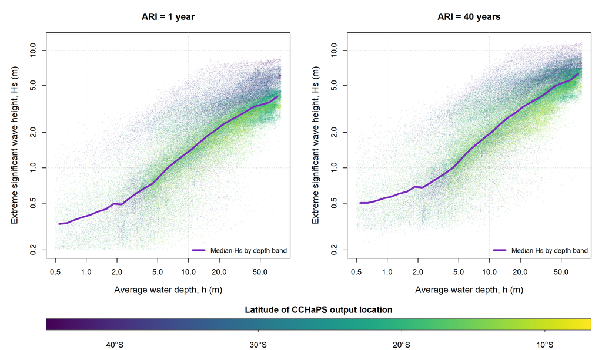

Figure 1. CCHaPS extreme significant wave height against average water depth for the 1-year ARI (left) and 40-year ARI (right). Sampled CCHaPS output locations are coloured by latitude using the full viridis scale. The purple curve in each panel shows the median significant wave height within logarithmically spaced depth bands, obtained by converting the median Hs/h ratio back to metres. Both axes are logarithmic, and the wave-height range is restricted to 0.2–12 m.

**Reading Figure 1.** The upper edge of the point cloud rises with depth because deeper water can support larger waves before depth-induced breaking becomes important. The full viridis colours show the broad north–south climate pattern without hiding the substantial overlap: a shallow but exposed coast can still be rougher than a deeper but sheltered gulf.

The ratio $H_s/h$ compares the event height with the water beneath it. It is **not** a universal breaking threshold, but a larger ratio indicates that the modelled sea state occupies a larger share of the available depth and is more likely to be affected by shallow-water processes. The purple curves express this diagnostic on the same wave-height axis as the point cloud: the median $H_s/h$ in each depth band is multiplied by the centre depth of that band to obtain a representative median $H_s$ in metres. The 40-year curve occupies a larger share of the available depth across more of the shelf, indicating a stronger depth constraint for the rarer event.

# 5 Where do the simple depth-and-latitude model relationships work—and where do they miss?

The figures below show mapped water depth, CCHaPS wave heights and the differences between CCHaPS and the simple depth-and-latitude model. Red residual areas show where CCHaPS estimates larger waves than the simple model, often in deeper or more exposed waters influenced by swell, regional storms or tropical cyclones. Blue residual areas show where CCHaPS estimates smaller waves, often in sheltered or fetch-limited waters or where wave energy has been reduced by friction and breaking. These differences are more visible for the rarer 40-year waves because a larger incoming event comes closer to the maximum size that shallow water can support.

The CCHaPS calculations are supplied at output locations on an unstructured mesh rather than on a regular raster. For plotting only, each output location is assigned to a regular 0.0125° longitude–latitude cell; where several output locations fall inside one cell, their values are averaged. Empty display cells are filled from their immediate neighbours for 3 short passes, then the rasters are clipped back to the fitted shelf-depth range and masked over land. This rasterisation closes small visual gaps and provides a consistent map grid, but it does not change the regressions, which are fitted to the original unstructured output locations.

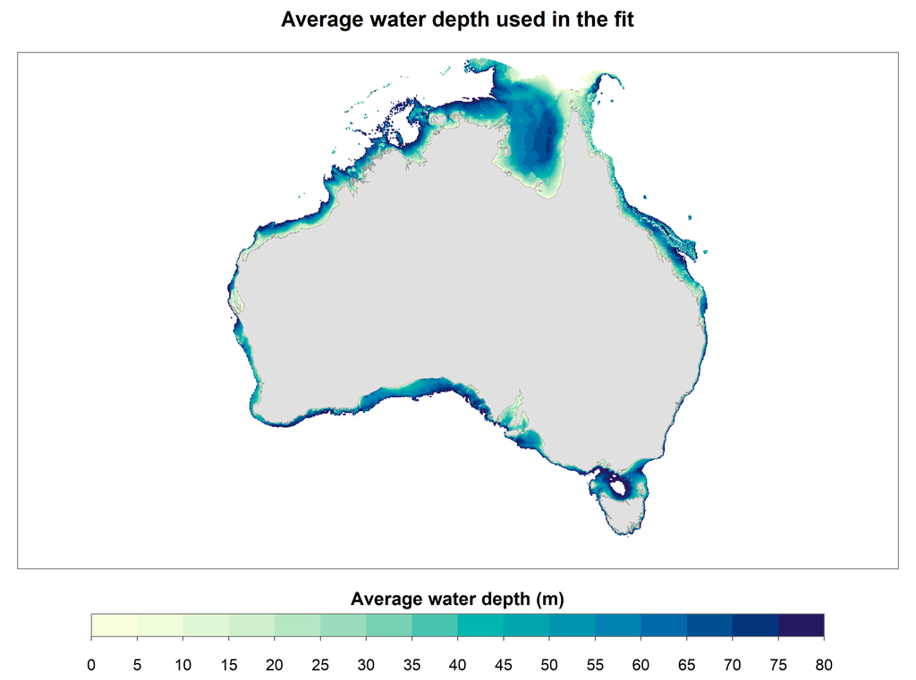

Figure 2. Average CCHaPS water depth across the fitted domain. Pale colours show shallow banks and inner shelves; darker blues show the deeper part of the fitted continental shelf. Areas outside the selected depth range are excluded from the analysis. This map has no logarithmic axis or colour transformation: depth is shown in linear 5 m intervals.

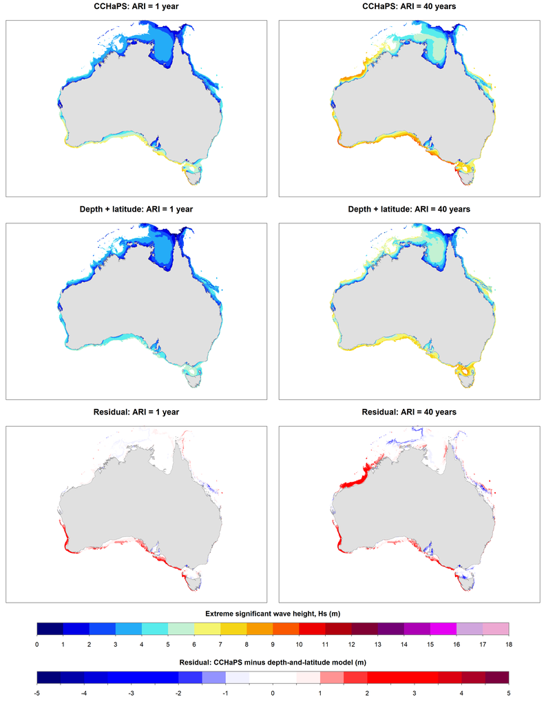

Figure 3. Extreme significant wave height across the fitted shelf-depth range. Columns compare the 1-year ARI (left) with the 40-year ARI (right). The top row is the full CCHaPS estimate, the middle row is the depth-and-latitude model, and the bottom row is the residual (CCHaPS minus the simple model). The two shared colour bars apply to the four wave-height panels and two residual panels, respectively. The mapped wave heights and residuals are untransformed values in metres on linear colour scales; no logarithmic axis or colour transformation is used.

```r
fit_map_domain <-
  is.finite(analysis_df$depth_m) &
  analysis_df$depth_m >= params$minimum_depth_m &
  analysis_df$depth_m <= params$maximum_depth_m

map_fields <- c(
  "depth_m",
  "Hs_ARI_1", "Hs_ARI_40",
  "Hs_ARI_1_depth_latitude_model", "Hs_ARI_40_depth_latitude_model",
  "Hs_ARI_1_depth_latitude_residual", "Hs_ARI_40_depth_latitude_residual"
)

map_data <- analysis_df[
  fit_map_domain,
  c("longitude", "latitude", map_fields)
]

map_points <- terra::vect(
  map_data,
  geom = c("longitude", "latitude"),
  crs = "EPSG:4326"
)

australia_template <- terra::rast(
  xmin = 110,
  xmax = 155,
  ymin = -45,
  ymax = -5,
  resolution = params$map_resolution_degrees,
  crs = "EPSG:4326"
)

raw_map_raster_list <- lapply(map_fields, function(field_name) {
  terra::rasterize(
    map_points,
    australia_template,
    field = field_name,
    fun = "mean",
    na.rm = TRUE
  )
})

raw_map_rasters <- terra::rast(raw_map_raster_list)
names(raw_map_rasters) <- map_fields

coastline <- terra::vect(input_files$coastline)
coastline <- terra::as.polygons(coastline)
coastline <- terra::project(coastline, "EPSG:4326")

fill_small_display_gaps <- function(raster_layer, passes = 2) {
  output <- raster_layer
  if (passes <= 0) return(output)

  for (pass_number in seq_len(passes)) {
    neighbour_mean <- terra::focal(
      output,
      w = 3,
      fun = "mean",
      na.rm = TRUE,
      na.policy = "only",
      fillvalue = NA
    )
    output <- terra::cover(output, neighbour_mean)
  }
  output
}

# Fill only the display rasters; the statistical models continue to use nodes.
filled_depth <- fill_small_display_gaps(
  raw_map_rasters[["depth_m"]],
  params$map_gap_fill_passes
)

fitted_shelf_mask <- terra::ifel(
  filled_depth >= params$minimum_depth_m &
    filled_depth <= params$maximum_depth_m,
  1,
  NA
)

coastline$land_mask_value <- 1
land_mask <- terra::rasterize(
  coastline,
  australia_template,
  field = "land_mask_value",
  background = NA
)

map_raster_list <- lapply(seq_len(terra::nlyr(raw_map_rasters)), function(i) {
  filled_layer <- fill_small_display_gaps(
    raw_map_rasters[[i]],
    params$map_gap_fill_passes
  )
  filled_layer <- terra::mask(filled_layer, fitted_shelf_mask)
  terra::mask(filled_layer, land_mask, inverse = TRUE)
})

map_rasters <- terra::rast(map_raster_list)
names(map_rasters) <- map_fields

plot_map_panel <- function(
  raster_layer,
  title,
  colours,
  breaks,
  show_legend = TRUE,
  title_cex = 1.15
) {
  if (show_legend) {
    terra::plot(
      raster_layer,
      col = colours,
      breaks = breaks,
      axes = FALSE,
      main = title,
      cex.main = title_cex,
      plg = list(cex = 0.8, title = "m")
    )
  } else {
    terra::plot(
      raster_layer,
      col = colours,
      breaks = breaks,
      axes = FALSE,
      main = title,
      cex.main = title_cex,
      legend = FALSE
    )
  }
  terra::plot(
    terra::crop(coastline, terra::ext(raster_layer)),
    add = TRUE,
    col = "grey88",
    border = "grey55",
    lwd = 0.25
  )
  box(col = "grey45")
}

draw_shared_colour_bar <- function(
  breaks,
  colours,
  label,
  tick_positions,
  tick_labels = tick_positions,
  axis_cex = 0.90,
  label_cex = 1.06
) {
  plot.new()
  plot.window(
    xlim = range(breaks) + c(-1, 1) * diff(range(breaks)) * 0.025,
    ylim = c(0, 1),
    xaxs = "i",
    yaxs = "i"
  )
  rect(
    xleft = breaks[-length(breaks)],
    ybottom = 0.46,
    xright = breaks[-1],
    ytop = 0.72,
    col = colours,
    border = NA
  )
  rect(
    xleft = min(breaks),
    ybottom = 0.46,
    xright = max(breaks),
    ytop = 0.72,
    border = "grey45"
  )
  axis(
    1,
    at = tick_positions,
    labels = tick_labels,
    pos = 0.46,
    cex.axis = axis_cex,
    tcl = -0.24,
    lwd = 0,
    lwd.ticks = 0.8,
    padj = 0.2
  )
  text(
    x = mean(range(breaks)),
    y = 0.98,
    labels = label,
    adj = c(0.5, 1),
    cex = label_cex,
    font = 2
  )
}
```

The wave-height colour scale runs from 0 to 18 m in 1 m increments: blues show values below 5 m, yellows and reds show values from 5 to 11 m, and browns, purples and pinks show values above 11 m. The residual display runs from -5 to 5 m in discrete 0.5 m increments. Blue means CCHaPS is lower than the depth-and-latitude estimate, white marks the transition around zero, and red or purple means CCHaPS is higher. Values outside the displayed residual range are clipped to its end colours.

**Explore the maps yourself**

Use the interactive map to switch between CCHaPS wave heights, the depth-and-latitude estimates, their residuals and the model bathymetry. Comparing the layers shows where the simple relationship closely follows CCHaPS and where exposure, sheltering and other regional wave processes produce larger differences.

Use the radio buttons at bottom left to switch between the CCHaPS estimate, depth-and-latitude model and residual for each ARI, or select the bathymetry layer to view the average water depth used in the analysis. The legend at top right changes automatically with the selected layer. The grey background is the Esri World Light Gray Canvas basemap. Small gaps in the regular display grid have been filled from neighbouring cells, while the fitted shelf-depth and land masks are retained.

[output not shown]

[interactive chart not shown]

**What do the red and blue residual areas show?**

The residual colours show the direction and size of the difference, not confidence or proof that either estimate is wrong. The red pattern is more evident for the 40-year ARI and typically occurs in deeper or more exposed water, including coasts exposed to Southern Ocean swell, parts of the North West Shelf and waters seaward of the Great Barrier Reef. Likely contributors include long fetch, tropical-cyclone or east-coast-low waves, coastline orientation, wave focusing and connections to deeper water.

Blue areas often occur inside sheltered gulfs, behind islands or reefs, across short fetches, or where bottom friction and repeated breaking remove energy before waves reach the model output location. White areas are close to zero residual, where the simple model and CCHaPS give similar wave heights. These regional interpretations are hypotheses to investigate rather than proof that any one process caused the residual.

Future analysis could separate the depth effect more cleanly by including offshore wave exposure, tropical-cyclone tracks, distance from the coast, shelf width, bathymetric slope, coastline orientation and fetch. A particularly useful next step would compare output locations with similar offshore wave forcing and latitude but different local depth.

# 6 What should surfers and wave-watchers take from this?

[output not shown]

# 7 Where does the depth-limited wave energy go?

Breaking creates turbulence, bubbles and noise, with most of the dissipated wave energy ultimately converted to heat. Breaking also contributes to wave setup, currents, infragravity motion and sediment transport. The lost wind-wave energy does not simply become one other wave type or coastal process; more detailed models are needed to simulate the individual waves and the resulting coastal responses.

Depth-induced breaking removes energy from the short-period wind-wave spectrum, but “dissipated” does not mean that all of the lost energy reappears in one other wave component. Breaking generates turbulence, entrains air as bubbles and produces noise, while most of the dissipated wave energy is ultimately converted to heat. At the same time, the shoreward reduction in wave momentum flux—usually described through radiation-stress gradients—changes mean water level through wave setup and forces cross-shore, rip and longshore currents. The foundations of these momentum transfers are described by [Longuet-Higgins and Stewart (1962)](https://doi.org/10.1017/S0022112062000877), with a classic longshore-current application in [Longuet-Higgins (1970)](https://doi.org/10.1029/JC075i033p06778).

Wave groups also create slow variations in wave energy and radiation stress. Bound long waves accompany the groups outside the surf zone. As the groups shoal and break, the moving breakpoint and group-varying breaking can generate or release free infragravity waves, observed as **surf beat**. [Symonds, Huntley and Bowen (1982)](https://doi.org/10.1029/JC087iC01p00492) describe this moving-breakpoint mechanism. It is an important pathway for transferring and generating low-frequency motion, but it does not imply that all short-wave energy lost during breaking becomes infragravity-wave energy.

Breaking turbulence, wave orbital motion and wave-driven currents can also mobilise the seabed. Sediment may move as bedload close to the bed or as suspended load in the water column. Spatial differences in that transport can build or erode bars, rip channels, ripples and other bedforms, altering the bathymetry that controls later waves. Models such as [XBeach](https://doi.org/10.1016/j.coastaleng.2009.08.006) couple wave groups and infragravity motion with currents, sediment transport and bed evolution for storm-impact studies. Currents and sediment transport should not, however, be treated as simple energy “bins”: the partition depends on wave period and angle, beach slope, water depth, sediment properties and the evolving morphology, while most broken-wave energy still cascades through turbulence to heat.

CCHaPS is a national, phase-averaged circulation-and-wave model. It represents bulk wave transformation and depth-induced breaking, but it is not intended to resolve each individual breaker, beach-scale infragravity motion or storm-driven bedform evolution. A future local analysis could combine CCHaPS offshore boundary conditions with observations and a finer surf-zone or morphodynamic model to track these energy and momentum pathways explicitly.

# 8 Looking ahead: sea-level rise and changing storms

Sea-level rise may allow larger waves to travel farther across currently shallow areas before breaking. The increase will not be one-for-one because wave periods, currents, seabed friction, changing storm conditions and the evolving offshore wave climate also affect the response.

Sea-level rise increases the water depth over reefs, banks and shallow shelves. Where waves are currently depth limited, additional depth may allow larger waves to travel farther shoreward before breaking. The response will not be a simple one-for-one increase because wave period, bottom friction, currents, changing storm tracks and changing offshore wave climate also matter.

This historical relationship should therefore not be assumed to remain fixed. A future version could repeat the analysis with the CCHaPS climate projections and separate the effects of changing water depth from changes in wind, storms and incoming wave spectra.

A further analysis could test the conceptual connection with the [Dean equilibrium beach profile](https://journals.flvc.org/jcr/article/view/78405), $h(x)=Ax^{2/3}$. If a local limiting wave height is approximated as $H_{\mathrm{lim}}\approx\gamma h$, then a Dean-like beach profile implies $H_{\mathrm{lim}}(x)\approx\gamma A x^{2/3}$. This would describe how a depth-limited wave ceiling changes with cross-shore distance; it would not imply that the national fitted depth exponent must equal $2/3$. A direct test would require shore-normal beach transects, distance from the coast, local sediment information or a fitted $A$, and comparable offshore wave forcing. The present output locations span shelves, gulfs, banks, reefs and non-equilibrium settings, so this report does not estimate $A$ or test the Dean exponent. The formulation and its applications are described further by [Dean (1991)](https://journals.flvc.org/jcr/article/download/78405/75816/).

# 9 The CCHaPS model and data

The 1981–2020 CCHaPS hindcast provides a nationally consistent representation of shelf and coastal wave conditions at finer resolution than the companion global analysis. It is still coarser than a dedicated local model of an individual beach, reef, bar or harbour.

CCHaPS is a national coupled circulation-and-wave model built on an unstructured coastal mesh. The hindcast covers 1981–2020 and simulates tides, storm surge, ocean currents and waves around Australia, with finer resolution near the coast.

The wave model is forced by downscaled atmospheric reanalysis data together with spectral wave conditions applied along the model boundary.

The hindcast, bathymetry, extreme-value outputs and model description are available from:

- [CCHaPS Hindcast for Australia](https://doi.org/10.25919/6tbn-px91);
- [CCHaPS Bathymetry for Australia](https://doi.org/10.25919/y0kc-a922);
- [Extreme Value Analysis of CCHaPS](https://doi.org/10.25919/0krs-nr55); and
- [Hernaman et al. (2026), CCHaPS development, implementation and validation](https://doi.org/10.1016/j.ocemod.2026.102731).

This report uses modelled significant wave height, $H_s$, bathymetric depth and mean modelled sea-surface height at every output location on the unstructured mesh. Average water depth for 1981–2020 is calculated as:

$$h = h_{\mathrm{bathymetry}} + \overline{\mathrm{zos}},$$

where bathymetry is positive downward and the overbar denotes the 1981–2020 mean sea-surface height relative to the model datum, the Australian Vertical Working Surface (AVWS; EPSG:9458).

# 10 Limits and reproducibility notes

These results are suitable for national-scale explanation and screening. They should not be treated as local surf forecasts, engineering-design values or substitutes for observations and high-resolution modelling.

- The depth-and-latitude model describes a national association; it does not isolate either variable as a causal effect.
- The latitude-only benchmark uses all valid positive water depths. The depth-only and depth-and-latitude models are restricted to 0.5–80 m and should not be extrapolated beyond those limits.
- The latitude-only model and the latitude term in the combined model are linear in $H_s$ metres. The depth exponent is estimated from the original $\log_{10}(H_s)$–$\log_{10}(h)$ relationship, and all performance metrics are evaluated in metres.
- The Dean profile connection is conceptual at this scale. This analysis does not estimate a beach-profile parameter $A$, use shore-normal distance, or test the $2/3$ profile exponent.
- The analysis uses Gumbel fits to annual maxima for consistency with the attached depth workflow. It does not compare alternative extreme-value distributions.
- A 40-year hindcast contains limited information about a 40-year ARI, particularly in tropical-cyclone regions. The uncertainty of the return level should be considered in any applied use.
- CCHaPS is a national model. Individual beaches, reefs, bars and harbour entrances may require substantially finer bathymetry and local modelling.
- Static and interactive maps rasterise the unstructured model output locations onto a regular 0.0125° display grid and fill only small neighbouring-cell gaps; model fitting uses the original output locations.
- The 0.0125° display grid contains sixteen times as many cells as the original 0.05° grid, increasing memory use, knitting time and HTML size without adding new model output locations.
- Display gap filling can smooth narrow channels or shelf-edge details and should not be used as a substitute for the original output values.
- The report describes offshore or shelf $H_s$, not the height of a breaking surf wave at a beach and not the largest individual wave.

**Input files**

The model input files used by this workflow are too large to include in the GitHub repository. They can be made available on request; the table below lists the expected filenames and their locations beneath `params$datadir`.

| Purpose | Expected file beneath `params$datadir` |
| --- | --- |
| Bathymetry and mesh coordinates | `depth_cchaps_hindcast_BARRA-R2_WHACS_ERA5_fx.nc` |
| Annual mean sea-surface height | `timeseries/zos_cchaps_hindcast_BARRA-R2_WHACS_ERA5_yr_mean_198101010000-202012310000.nc` |
| Gumbel fits to annual-maximum $H_s$ | `EVA/hs_cchaps_hindcast_BARRA-R2_WHACS_ERA5_yr_max_198101010000-202012310000_fgumbel.nc` |
| Australian coastline polygons | `LGA_2023_AUST_GDA2020_coastline` |

**Data sources**

The fitted Gumbel parameters and return-level information used here come from the CSIRO Data Access Portal collection [*Extreme Value Analysis of CCHaPS*](https://data.csiro.au/collection/csiro%3A65867). The bathymetry, mesh coordinates and mean water levels are from the associated CCHaPS hindcast files listed above.

For further reading about the CCHaPS model design, implementation and validation, see:

Hernaman, V., et al. (2026). *The Australian Climate Service Coupled circulation-wave Coastal Hazards Prediction System (CCHaPS): Development, implementation, and validation*. **Ocean Modelling, 202**, 102731. https://doi.org/10.1016/j.ocemod.2026.102731

The questions in this explainer adapt the familiar structure of a scientific article—introduction, aim, methods, results and discussion—into a more accessible conversation. They move from the purpose of the analysis and why it matters, through the physical explanation and analytical approach, to the main findings, their meaning and the limitations of the simplified relationships. This question-led structure retains the logic and scientific rigour of a journal article while helping readers understand what was investigated, how it was investigated, what was found and where more detailed numerical modelling is needed.

This layered format follows the idea behind CoastAdapt’s [*Skimmers, Waders and Divers*](https://coastadapt-uat.ers.tst.ce.griffith.edu.au/about-coastadapt/coastadapt-information-are-you-a-skimmer-wader-or-diver/) framework.